# Práctica 2

# Práctica 2

## Ejercicio 2.3.2

Recomendación de películas con el dataset Movielense:

- Lee la descripción del dataset MovieLense en la librería “recommenderlab” (Pg. 14).
- Carga ahora el dataset MovieLense: `data("MovieLense")`.
- (Sección 5.4) Inprecciona las propiedades del dataset y compáralo con el dataset Jester5k.
- Realiza un estudio y comparación similar al ejercicio anterior:
  - Visualiza la matriz de valoraciones (100 primeras filas y columnas) con la función `image()`.
  - (Sección 5.5) Crea un recomendador con las indicaciones del tutorial. Crea otra versión del recomendador con solo los 100 primeros usuarios y vuelve a predecir los usuarios 101 y 102. ¿Detectas diferencias en las recomendaciones?
  - (Secciones 5.6 y 5.7) Evalúa las recomendaciones siguiendo el tutorial. ¿Qué diferencia hay entre la evaluación de la sección 5.6 y la 5.7?¿Cuál te parece más apropiada para un sistema de recomendación?
  - (Sección 5.8) Compara los diferentes métodos de recomendación de esta sección. ¿Cómo quedaría el algoritmo de recomendación ítem-based en comparación con los utilizados en este sección?¿Cambian los resultados si modificamos el particionamiento utilizado en el procedimiento de evaluación?

```r
# Cargamos el dataset
data("MovieLense")

# Inspeccionamos las propiedades del dataset
cat("Dimensiones de MovieLense: ", dim(MovieLense), "\n")
```

```
## Dimensiones de MovieLense:  943 1664
```

```r
cat("Número total de valoraciones: ", sum(rowCounts(MovieLense)), "\n")
```

```
## Número total de valoraciones:  99392
```

```r
cat("Rango de calificaciones: ", range(getRatings(MovieLense)), "\n")
```

```
## Rango de calificaciones:  1 5
```

```r
cat("Densidad de la matriz: ", sum(rowCounts(MovieLense)) / (nrow(MovieLense) * ncol(MovieLense)), "\n")
```

```
## Densidad de la matriz:  0.06334122
```

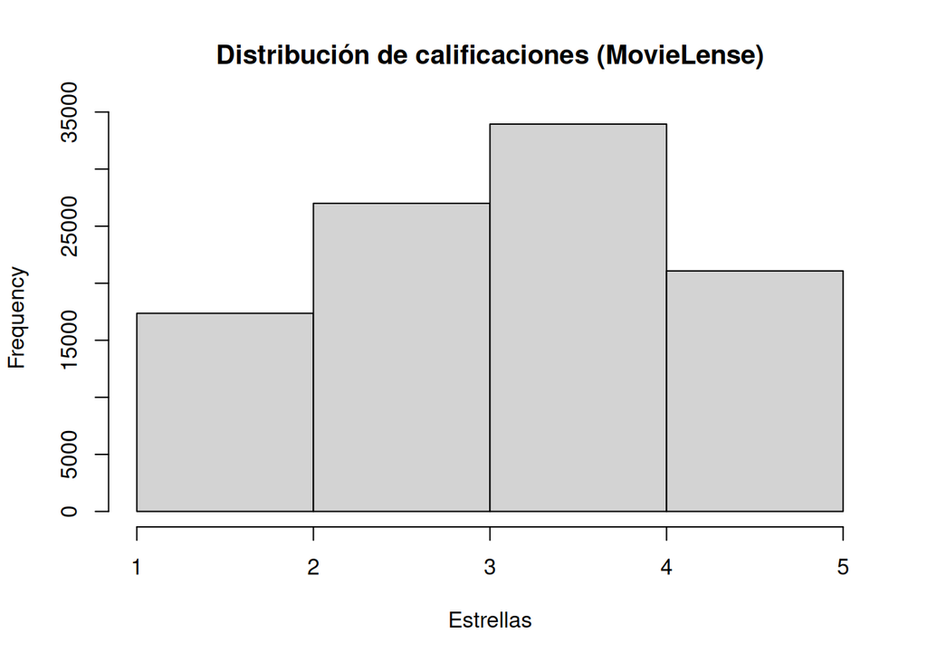

```r
hist(getRatings(MovieLense), breaks = 5, main = "Distribución de calificaciones (MovieLense)", xlab = "Estrellas")
```

```r
data("Jester5k")

cat("\nComparación con Jester5k:\n")
```

```
##
## Comparación con Jester5k:
```

```r
cat("Dimensiones Jester5k: ", dim(Jester5k), "\n")
```

```
## Dimensiones Jester5k:  5000 100
```

```r
cat("Rango de Jester5k: ", range(getRatings(Jester5k)), "\n")
```

```
## Rango de Jester5k:  -9.95 9.9
```

```r
cat("Densidad Jester5k: ", sum(rowCounts(Jester5k)) / (nrow(Jester5k) * ncol(Jester5k)), "\n")
```

```
## Densidad Jester5k:  0.726418
```

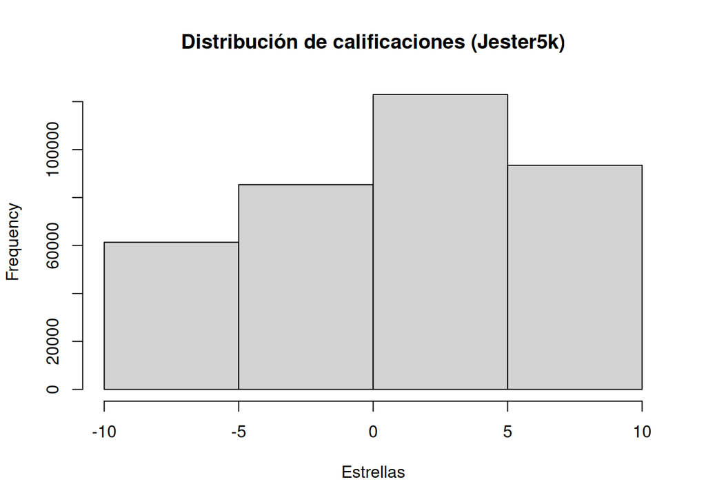

```r
hist(getRatings(Jester5k), breaks = 5, main = "Distribución de calificaciones (Jester5k)", xlab = "Estrellas")
```

Podemos ver que el dataset Jester5k tiene dimensiones $5000\times 100$. Los elementos tienen un rango de entre -10 y 10 (aunque no se encuentran estos valores en las respuestas), por lo que el sistema de puntuación es diferente al de MovieLense. Además, la densidad del dataset Jester5k es mucho mayor que la de MovieLense. Podemos ver que la distribución de notas es parecida a la de MovieLense.

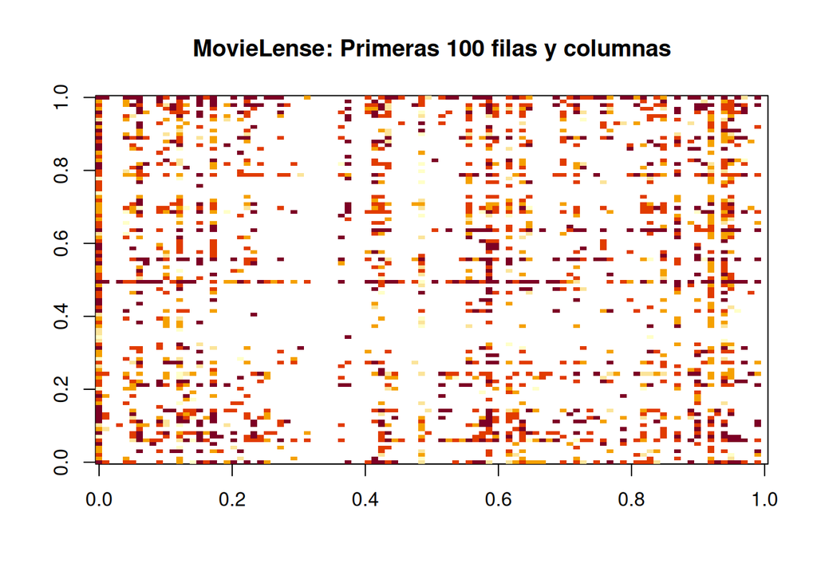

```r
# Visualizamos la matriz
ml_matrix <- as(MovieLense[1:100, 1:100], "matrix")
image(ml_matrix, main = "MovieLense: Primeras 100 filas y columnas")
```

Se puede ver como la matriz es muy dispersa, con muchas calificaciones vacías.

```r
# Creamos un recomendador usando el método "POPULAR"
recommender <- Recommender(MovieLense, method = "POPULAR")

# Predecimos las 5 recomendaciones para los usuarios 1001 y 1002
pred <- predict(recommender, MovieLense[101:102, ], n = 5)
as(pred, "list")
```

```
## $`101`
## [1] "Godfather, The (1972)"            "Fargo (1996)"
## [3] "Raiders of the Lost Ark (1981)"   "Silence of the Lambs, The (1991)"
## [5] "Titanic (1997)"
##
## $`102`
## [1] "Fargo (1996)"                     "Schindler's List (1993)"
## [3] "Shawshank Redemption, The (1994)" "Usual Suspects, The (1995)"
## [5] "Casablanca (1942)"
```

```r
# Creamos un recomendador usando el método "POPULAR" y solo los 100 primeros usuarios
recommender.100 <- Recommender(MovieLense[1:100, ], method = "POPULAR")

# Predecimos las 5 recomendaciones para los usuarios 101 y 102 (en el dataset completo)
pred.100 <- predict(recommender.100, MovieLense[101:102, ], n = 5)
as(pred.100, "list")
```

```
## $`101`
## [1] "Fargo (1996)"                     "Raiders of the Lost Ark (1981)"
## [3] "Shawshank Redemption, The (1994)" "Pulp Fiction (1994)"
## [5] "Silence of the Lambs, The (1991)"
##
## $`102`
## [1] "Fargo (1996)"                     "Shawshank Redemption, The (1994)"
## [3] "Usual Suspects, The (1995)"       "Schindler's List (1993)"
## [5] "Dead Man Walking (1995)"
```

```r
# Vemos los elementos que coinciden en ambas predicciones
pred.list <- as(pred, "list")
pred.100.list <- as(pred.100, "list")
common.items <- intersect(pred.list[[1]], pred.100.list[[1]])
print("Elementos comunes en las recomendaciones de ambos modelos:")
```

```
## [1] "Elementos comunes en las recomendaciones de ambos modelos:"
```

```r
print(common.items)
```

```
## [1] "Fargo (1996)"                     "Raiders of the Lost Ark (1981)"
## [3] "Silence of the Lambs, The (1991)"
```

```r
common.items <- intersect(pred.list[[2]], pred.100.list[[2]])
print("Elementos comunes en las recomendaciones de ambos modelos:")
```

```
## [1] "Elementos comunes en las recomendaciones de ambos modelos:"
```

```r
print(common.items)
```

```
## [1] "Fargo (1996)"                     "Schindler's List (1993)"
## [3] "Shawshank Redemption, The (1994)" "Usual Suspects, The (1995)"
```

Vamos a realizar una evaluación usando “predicted ragings”

```r
# ECreamos un esquema de evaluación
eval.scheme <- evaluationScheme(MovieLense, method = "split", train = 0.9, given = 15, goodRating = 3.75)
eval.scheme
```

```
## Evaluation scheme with 15 items given
## Method: 'split' with 1 run(s).
## Training set proportion: 0.900
## Good ratings: >=3.750000
## Data set: 943 x 1664 rating matrix of class 'realRatingMatrix' with 99392 ratings.
```

```r
# Creamos dos recomendadores, uno con UBCF y otro con IBCF
recommender.ubcf <- Recommender(getData(eval.scheme, "train"), method = "UBCF")
recommender.ibcf <- Recommender(getData(eval.scheme, "train"), method = "IBCF")

# Predecimos las recomendaciones de cada uno usando tupo "ratings"
predict.ubcf <- predict(recommender.ubcf, getData(eval.scheme, "known"), type = "ratings")
predict.ibcf <- predict(recommender.ibcf, getData(eval.scheme, "known"), type = "ratings")

# Finalmente calculamos los errores
error <- rbind(
    ubcf = calcPredictionAccuracy(predict.ubcf, getData(eval.scheme, "unknown")),
    ibcf = calcPredictionAccuracy(predict.ibcf, getData(eval.scheme, "unknown"))
)
error
```

```
##          RMSE      MSE       MAE
## ubcf 1.229827 1.512475 0.9691213
## ibcf 1.684399 2.837201 1.2974684
```

Vamos a realizar una evaluación usando “top-N”

```r
# Creamos un esquema de evaluación
eval.scheme <- evaluationScheme(MovieLense, method = "split", train = 0.9, given = 3, goodRating = 3.75)

# Generamos resultados con el método top-N
results <- evaluate(eval.scheme, method = "POPULAR", type = "topNList", n = c(1, 3, 5, 10, 15, 20))
```

```
## POPULAR run fold/sample [model time/prediction time]
##   1  [0.004sec/0.135sec]
```

```r
results
```

```
## Evaluation results for 1 folds/samples using method 'POPULAR'.
```

```r
getConfusionMatrix(results)[[1]]
```

```
##             TP        FP       FN       TN        N precision      recall
## [1,] 0.4947368 0.2842105 65.00000 1594.789 1660.568 0.6351351 0.008355768
## [2,] 1.2631579 1.0736842 64.23158 1594.000 1660.568 0.5405405 0.020194103
## [3,] 1.8842105 2.0105263 63.61053 1593.063 1660.568 0.4837838 0.031150618
## [4,] 3.5052632 4.2842105 61.98947 1590.789 1660.568 0.4500000 0.055396052
## [5,] 4.8736842 6.8105263 60.62105 1588.263 1660.568 0.4171171 0.075765092
## [6,] 6.0421053 9.5368421 59.45263 1585.537 1660.568 0.3878378 0.091680396
##              TPR          FPR  n
## [1,] 0.008355768 0.0001754110  1
## [2,] 0.020194103 0.0006659275  3
## [3,] 0.031150618 0.0012524829  5
## [4,] 0.055396052 0.0026705241 10
## [5,] 0.075765092 0.0042497015 15
## [6,] 0.091680396 0.0059553423 20
```

```r
avg(results)
```

```
##             TP        FP       FN       TN        N precision      recall
## [1,] 0.4947368 0.2842105 65.00000 1594.789 1660.568 0.6351351 0.008355768
## [2,] 1.2631579 1.0736842 64.23158 1594.000 1660.568 0.5405405 0.020194103
## [3,] 1.8842105 2.0105263 63.61053 1593.063 1660.568 0.4837838 0.031150618
## [4,] 3.5052632 4.2842105 61.98947 1590.789 1660.568 0.4500000 0.055396052
## [5,] 4.8736842 6.8105263 60.62105 1588.263 1660.568 0.4171171 0.075765092
## [6,] 6.0421053 9.5368421 59.45263 1585.537 1660.568 0.3878378 0.091680396
##              TPR          FPR  n
## [1,] 0.008355768 0.0001754110  1
## [2,] 0.020194103 0.0006659275  3
## [3,] 0.031150618 0.0012524829  5
## [4,] 0.055396052 0.0026705241 10
## [5,] 0.075765092 0.0042497015 15
## [6,] 0.091680396 0.0059553423 20
```

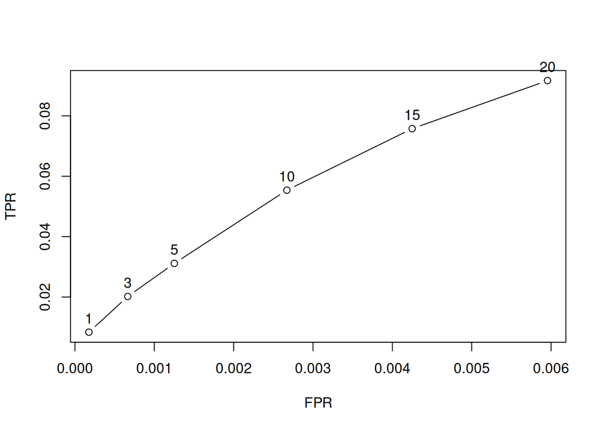

```r
plot(results, annotate = TRUE)
```

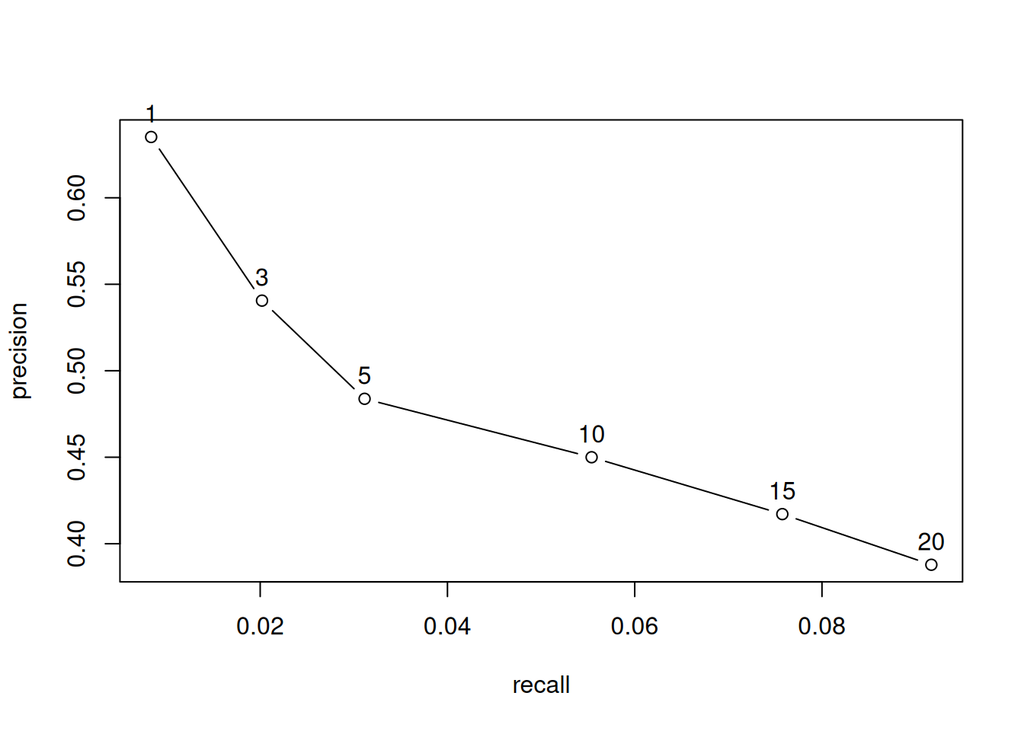

```r
plot(results, "prec/rec", annotate = TRUE)
```

## Ejercicio 2.3.3

Crear un recomendador basado en factorización matricial. Se pone a vuestro disposición un paper que describe dicho algoritmo y lo compara con las alternartivas más populares. Se os pide entrenar el algoritmo con el dataset de Movielens y comparar sus recomendaciones con los recomendadores “popular”, “user-based” y “item-based”. Se os proporciona un tutorial para poder trabajar con el algoritmos en el entorno R: http://www.r-bloggers.com/matrix-factorization/.

```r
# Cargar librerías necesarias
library(recommenderlab) # Para el dataset Movielens y métodos recomendadores
library(Matrix) # Para operaciones con matrices (si se requiere)
library(reshape2) # Para dar forma a los datos si es necesario

# ------------------------------------------------------------------
# 1. Preparación de los datos: Dataset Movielens
# ------------------------------------------------------------------

# Se carga el dataset de Movielens (disponible en recommenderlab)
data("MovieLense")
ratings <- as(MovieLense, "matrix")

# Creamos una matriz R que indique dónde existen ratings (1 para observados, 0 para NA)
R_mat <- ifelse(is.na(ratings), 0, 1)
# Reemplazamos los NA en Y (matriz de ratings) por 0 para el cálculo
Y <- ratings
Y[is.na(Y)] <- 0

# Definir dimensiones y número de características latentes (factores)
num_users <- nrow(Y)
num_movies <- ncol(Y)
num_features <- 10 # Número de factores latentes (puede ajustarse)
lambda <- 10 # Parámetro de regularización

# ------------------------------------------------------------------
# 2. Definición de la función de coste y su gradiente
# Basada en la función:
# J = 0.5 * sum((R * (Y - X %*% t(Theta)))^2) + (lambda/2) * (||X||^2 + ||Theta||^2)
# donde X representa la representación de usuarios y Theta la de películas.
# ------------------------------------------------------------------

costFunction <- function(params, Y, R, num_users, num_movies, num_features, lambda) {
    # Se separan los parámetros en X y Theta
    X <- matrix(params[1:(num_users * num_features)], nrow = num_users, ncol = num_features)
    Theta <- matrix(params[(num_users * num_features + 1):length(params)],
        nrow = num_movies, ncol = num_features
    )

    # Predicciones y error solo en las entradas observadas
    predictions <- X %*% t(Theta)
    error <- (predictions - Y) * R # se ignoran los NA (donde R=0)

    # Cálculo del coste con regularización
    cost <- 0.5 * sum(error^2) + (lambda / 2) * (sum(X^2) + sum(Theta^2))

    # Gradientes para X y Theta
    X_grad <- error %*% Theta + lambda * X
    Theta_grad <- t(error) %*% X + lambda * Theta

    grad <- c(as.vector(X_grad), as.vector(Theta_grad))

    # La función optim() con L-BFGS-B espera retornar coste y gradiente por separado
    list(value = cost, gradient = grad)
}

# ------------------------------------------------------------------
# 3. Inicialización y entrenamiento del modelo de factorización matricial
# ------------------------------------------------------------------

# Inicialización aleatoria de X y Theta
set.seed(123) # para reproducibilidad
X_init <- matrix(runif(num_users * num_features, 0, 1), nrow = num_users, ncol = num_features)
Theta_init <- matrix(runif(num_movies * num_features, 0, 1), nrow = num_movies, ncol = num_features)
initial_params <- c(as.vector(X_init), as.vector(Theta_init))

# Optimización usando optim() con el método L-BFGS-B
result <- optim(initial_params,
    fn = function(p) costFunction(p, Y, R_mat, num_users, num_movies, num_features, lambda)$value,
    gr = function(p) costFunction(p, Y, R_mat, num_users, num_movies, num_features, lambda)$gradient,
    method = "L-BFGS-B",
    control = list(maxit = 100)
)

# Recuperar los parámetros optimizados
trained_params <- result$par
X_trained <- matrix(trained_params[1:(num_users * num_features)], nrow = num_users, ncol = num_features)
Theta_trained <- matrix(trained_params[(num_users * num_features + 1):length(trained_params)],
    nrow = num_movies, ncol = num_features
)

# Calcular la matriz de predicción de ratings
predicted_ratings <- X_trained %*% t(Theta_trained)

# Función para obtener recomendaciones para un usuario dado
recommendForUser <- function(user_id, pred_matrix, R, n = 5) {
    # No recomendar películas ya calificadas
    user_pred <- pred_matrix[user_id, ]
    user_pred[which(R[user_id, ] == 1)] <- -Inf
    # Seleccionar los n índices con mayor puntuación
    recommended <- order(user_pred, decreasing = TRUE)[1:n]
    return(recommended)
}

# Ejemplo: recomendaciones para el usuario 1
cat("Recomendaciones (fact. matricial) para el usuario 1:\n")
```

```
## Recomendaciones (fact. matricial) para el usuario 1:
```

```r
print(recommendForUser(1, predicted_ratings, R_mat, n = 5))
```

```
## [1] 405 301 275 284 507
```

```r
# ------------------------------------------------------------------
# 4. Comparación con otros métodos de recomendación: Popular, UBCF e IBCF
# Se utilizará el paquete recommenderlab para estos métodos.
# ------------------------------------------------------------------

# Método basado en popularidad
pop_recommender <- Recommender(MovieLense, method = "POPULAR")
pop_pred <- predict(pop_recommender, MovieLense[1], n = 5)
cat("\nRecomendaciones (POPULAR) para el usuario 1:\n")
```

```
##
## Recomendaciones (POPULAR) para el usuario 1:
```

```r
print(as(pop_pred, "list"))
```

```
## $`1`
## [1] "Titanic (1997)"
## [2] "Schindler's List (1993)"
## [3] "L.A. Confidential (1997)"
## [4] "Casablanca (1942)"
## [5] "One Flew Over the Cuckoo's Nest (1975)"
```

```r
# Método colaborativo basado en usuarios (UBCF)
ubcf_recommender <- Recommender(MovieLense, method = "UBCF")
ubcf_pred <- predict(ubcf_recommender, MovieLense[1], n = 5)
cat("\nRecomendaciones (User-Based Collaborative Filtering) para el usuario 1:\n")
```

```
##
## Recomendaciones (User-Based Collaborative Filtering) para el usuario 1:
```

```r
print(as(ubcf_pred, "list"))
```

```
## $`0`
## [1] "Boot, Das (1981)"                 "Matilda (1996)"
## [3] "Winter Guest, The (1997)"         "She's the One (1996)"
## [5] "Manchurian Candidate, The (1962)"
```

```r
# Método colaborativo basado en ítems (IBCF)
ibcf_recommender <- Recommender(MovieLense, method = "IBCF")
ibcf_pred <- predict(ibcf_recommender, MovieLense[1], n = 5)
cat("\nRecomendaciones (Item-Based Collaborative Filtering) para el usuario 1:\n")
```

```
##
## Recomendaciones (Item-Based Collaborative Filtering) para el usuario 1:
```

```r
print(as(ibcf_pred, "list"))
```

```
## $`0`
## [1] "Entertaining Angels: The Dorothy Day Story (1996)"
## [2] "Big Bang Theory, The (1994)"
## [3] "They Made Me a Criminal (1939)"
## [4] "Cyclo (1995)"
## [5] "King of New York (1990)"
```